# 🛍️ Mall Customer Segmentation using Unsupervised Learning

### PR-1: Unsupervised Learning

**Institute:** Red & White Skill Education  
**Subject:** Unsupervised Learning  
**Project:** Mall Customer Segmentation using Clustering Algorithms

## Algorithms Used

- K-Means Clustering
- Agglomerative Hierarchical Clustering
- DBSCAN

# 📌 Project Overview

Customer segmentation is one of the most important applications of Unsupervised Machine Learning in retail analytics. Instead of predicting a target value, clustering algorithms automatically group customers with similar characteristics and purchasing behaviour.

In this project, the **Mall Customer Segmentation** dataset is analysed using three popular clustering algorithms:

- K-Means Clustering
- Agglomerative Hierarchical Clustering
- DBSCAN

The dataset contains customer demographic information such as **Gender**, **Age**, **Annual Income**, and **Spending Score**. By identifying natural customer groups, businesses can better understand customer behaviour and create targeted marketing strategies.

# 🎯 Project Objectives

The objectives of this project are to:

- Load and explore the Mall Customer Segmentation dataset.
- Perform data preprocessing and feature engineering.
- Encode categorical features.
- Apply feature scaling using **StandardScaler**.
- Perform Exploratory Data Analysis (EDA).
- Implement K-Means Clustering.
- Implement Agglomerative Hierarchical Clustering.
- Implement DBSCAN Clustering.
- Compare all clustering algorithms.
- Generate meaningful business insights from customer segments.

# Task 1: Data Loading & Exploratory Data Analysis (EDA)

### Objective

Load the Mall Customer dataset, perform basic preprocessing, and explore the customer data to understand its distribution before applying clustering algorithms.

### Expected Output

- Dataset loaded successfully.
- Dataset cleaned and prepared for analysis.
- Gender encoded into numerical values.
- Histograms for numerical features.
- Pairplot and Correlation Heatmap.
- Summary of key observations from the data.

```python
# Import Required Libraries


import warnings
warnings.filterwarnings("ignore")

import numpy as np
import pandas as pd
import matplotlib.pyplot as plt
import seaborn as sns

from sklearn.preprocessing import LabelEncoder, StandardScaler

from sklearn.cluster import KMeans, AgglomerativeClustering, DBSCAN

from sklearn.metrics import silhouette_score, davies_bouldin_score, calinski_harabasz_score

from scipy.cluster.hierarchy import dendrogram, linkage

from sklearn.neighbors import NearestNeighbors

pd.set_option("display.max_columns", None)
pd.set_option("display.width", 1000)

# Plot Style
sns.set_style("whitegrid")
plt.rcParams["figure.figsize"] = (8, 5)
plt.rcParams["axes.titlesize"] = 14
plt.rcParams["axes.labelsize"] = 12
plt.rcParams["axes.titleweight"] = "bold"
```

### Task 1.1: Load the Dataset

```python
df = pd.read_csv("../data/Mall_Customers.csv")
df.head()
```

|  | CustomerID | Gender | Age | Annual Income (k$) | Spending Score (1-100) |
| --- | --- | --- | --- | --- | --- |
| 0 | 1 | Male | 19 | 15 | 39 |
| 1 | 2 | Male | 21 | 15 | 81 |
| 2 | 3 | Female | 20 | 16 | 6 |
| 3 | 4 | Female | 23 | 16 | 77 |
| 4 | 5 | Female | 31 | 17 | 40 |

```python
df.info()
```

```
<class 'pandas.core.frame.DataFrame'>
RangeIndex: 200 entries, 0 to 199
Data columns (total 5 columns):
 #   Column                  Non-Null Count  Dtype
---  ------                  --------------  -----
 0   CustomerID              200 non-null    int64
 1   Gender                  200 non-null    object
 2   Age                     200 non-null    int64
 3   Annual Income (k$)      200 non-null    int64
 4   Spending Score (1-100)  200 non-null    int64
dtypes: int64(4), object(1)
memory usage: 7.9+ KB
```

```python
df.describe()
```

|  | CustomerID | Age | Annual Income (k$) | Spending Score (1-100) |
| --- | --- | --- | --- | --- |
| count | 200.000000 | 200.000000 | 200.000000 | 200.000000 |
| mean | 100.500000 | 38.850000 | 60.560000 | 50.200000 |
| std | 57.879185 | 13.969007 | 26.264721 | 25.823522 |
| min | 1.000000 | 18.000000 | 15.000000 | 1.000000 |
| 25% | 50.750000 | 28.750000 | 41.500000 | 34.750000 |
| 50% | 100.500000 | 36.000000 | 61.500000 | 50.000000 |
| 75% | 150.250000 | 49.000000 | 78.000000 | 73.000000 |
| max | 200.000000 | 70.000000 | 137.000000 | 99.000000 |

```python
# Shape of Dataset
print(f"Number of Rows    : {df.shape[0]}")
print(f"Number of Columns : {df.shape[1]}")
```

```
Number of Rows    : 200
Number of Columns : 5
```

### Task 1.2: Rename Columns and Drop CustomerID

```python
df.rename(columns= {"Annual Income (k$)": "Annual_Income",
                    "Spending Score (1-100)": "Spending_Score"},
          inplace=True)
```

```python
# Drop CustomerID Column
df.drop("CustomerID", axis=1, inplace=True)
```

```python
# Display Updated Dataset
df.head()
```

|  | Gender | Age | Annual_Income | Spending_Score |
| --- | --- | --- | --- | --- |
| 0 | Male | 19 | 15 | 39 |
| 1 | Male | 21 | 15 | 81 |
| 2 | Female | 20 | 16 | 6 |
| 3 | Female | 23 | 16 | 77 |
| 4 | Female | 31 | 17 | 40 |

```python
print("Updated Shape :", df.shape)
```

```
Updated Shape : (200, 4)
```

### Task 1.3: Encode Gender

```python
label_encoder = LabelEncoder()

df["Gender"] = label_encoder.fit_transform(df["Gender"])

df.head()
```

|  | Gender | Age | Annual_Income | Spending_Score |
| --- | --- | --- | --- | --- |
| 0 | 1 | 19 | 15 | 39 |
| 1 | 1 | 21 | 15 | 81 |
| 2 | 0 | 20 | 16 | 6 |
| 3 | 0 | 23 | 16 | 77 |
| 4 | 0 | 31 | 17 | 40 |

### Task 1.4: Univariate Distribution Analysis

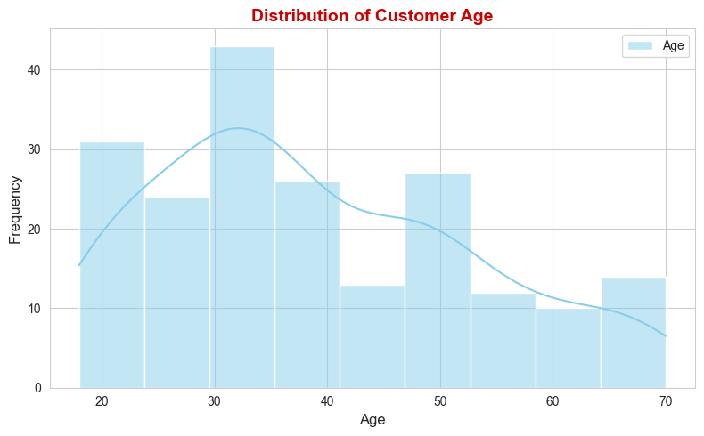

```python
plt.figure(figsize=(8, 5))

sns.histplot(data=df, x="Age", kde=True, color="skyblue", label="Age")

plt.title("Distribution of Customer Age", color="#CC0000", fontweight="bold")
plt.xlabel("Age")
plt.ylabel("Frequency")
plt.legend()

plt.tight_layout()
plt.savefig("../screenshots/age_distribution.png", dpi=300, bbox_inches="tight")
plt.show()
```

#### Interpretation

- The age distribution is concentrated between **20 and 40 years**.
- Most customers belong to the young and middle-aged groups.
- The distribution appears moderately spread without extreme outliers.

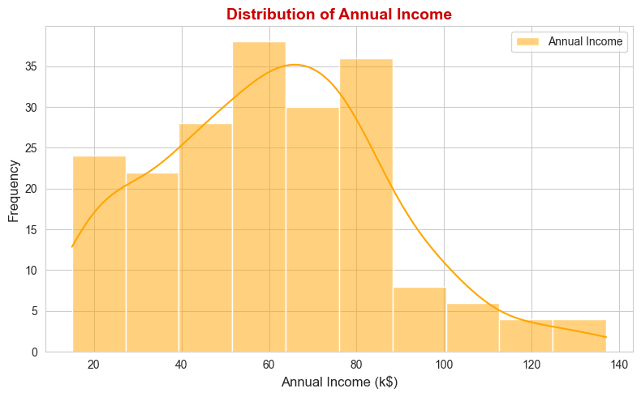

```python
plt.figure(figsize=(8, 5))

sns.histplot(data=df, x="Annual_Income", kde=True, color="orange", label="Annual Income")

plt.title("Distribution of Annual Income", color="#CC0000", fontweight="bold")
plt.xlabel("Annual Income (k$)")
plt.ylabel("Frequency")
plt.legend()

plt.tight_layout()
plt.savefig("../screenshots/annual_income_distribution.png", dpi=300, bbox_inches="tight")
plt.show()
```

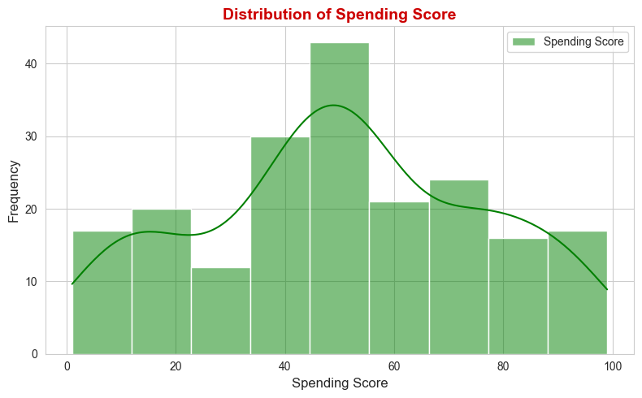

```python
plt.figure(figsize=(8, 5))

sns.histplot(data=df, x="Spending_Score", kde=True, color="green", label="Spending Score")

plt.title("Distribution of Spending Score", color="#CC0000", fontweight="bold")
plt.xlabel("Spending Score")
plt.ylabel("Frequency")
plt.legend()

plt.tight_layout()
plt.savefig("../screenshots/spending_score_distribution.png", dpi=300, bbox_inches="tight")
plt.show()
```

#### Interpretation

- Spending scores are spread across the full range (1–100).
- The distribution suggests the presence of customers with both low and high spending behaviour.
- This feature is likely to play a key role in distinguishing customer segments.

### Task 1.5: Pairplot and Correlation Heatmap

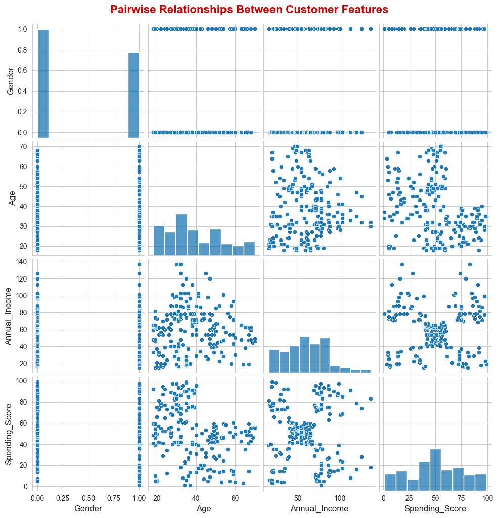

```python
pairplot = sns.pairplot(df)

pairplot.fig.suptitle("Pairwise Relationships Between Customer Features", color="#CC0000", fontweight="bold", fontsize=16, y=1.02)

pairplot.savefig("../screenshots/pairplot.png", dpi=300, bbox_inches="tight")
plt.show()
```

#### Interpretation

- The pairplot reveals potential customer groupings, particularly between **Annual Income** and **Spending Score**.
- **Age** shows a wider spread and does not exhibit clear clustering patterns.
- The combination of **Annual Income** and **Spending Score** appears to be the most suitable feature pair for visualizing customer segments.

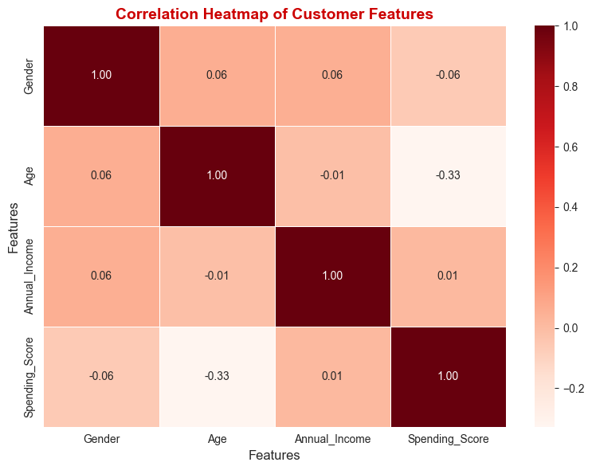

```python
plt.figure(figsize=(8, 6))

sns.heatmap(df.corr(), annot=True, cmap="Reds", fmt=".2f", linewidths=0.5)

plt.title("Correlation Heatmap of Customer Features", color="#CC0000", fontweight="bold")
plt.xlabel("Features")
plt.ylabel("Features")

plt.tight_layout()
plt.savefig("../screenshots/correlation_heatmap.png", dpi=300, bbox_inches="tight")
plt.show()
```

#### Interpretation

- Most feature pairs exhibit **weak correlations**, indicating that each feature contributes unique information.
- **Annual Income** and **Spending Score** have only a slight linear relationship, suggesting that clustering can uncover hidden customer groups beyond simple correlations.
- Since no feature pair is highly correlated, using all features for clustering is appropriate.

### Task 1.6: EDA Summary

#### Key Observations

- The pairplot indicates potential customer groupings, especially when comparing **Annual_Income** and **Spending_Score**.
- The correlation heatmap shows **no strong linear correlations** among the features, suggesting that each feature contributes unique information.
- **Age** appears to have a wider spread but does not clearly separate customers into distinct groups.
- **Annual_Income** and **Spending_Score** are the most suitable features for visualizing customer segments because customers with similar incomes often exhibit different spending behaviours, making natural clusters easier to identify.
- These observations suggest that clustering algorithms such as **K-Means**, **Agglomerative Clustering**, and **DBSCAN** can effectively discover meaningful customer segments.

# Task 2: Feature Scaling & Feature Selection

### Objective

Scale the numerical features and prepare the dataset for clustering by selecting the most suitable features.

### Expected Output

- Numerical features scaled using StandardScaler.
- A new DataFrame containing the scaled features.
- A two-feature subset prepared for clustering.

### Task 2.1: Scale Features

```python
scaler = StandardScaler()

df_scaled = df.copy()

df_scaled[["Age", "Annual_Income", "Spending_Score"]] = scaler.fit_transform(df_scaled[["Age", "Annual_Income", "Spending_Score"]])

df_scaled.head()
```

|  | Gender | Age | Annual_Income | Spending_Score |
| --- | --- | --- | --- | --- |
| 0 | 1 | -1.424569 | -1.738999 | -0.434801 |
| 1 | 1 | -1.281035 | -1.738999 | 1.195704 |
| 2 | 0 | -1.352802 | -1.700830 | -1.715913 |
| 3 | 0 | -1.137502 | -1.700830 | 1.040418 |
| 4 | 0 | -0.563369 | -1.662660 | -0.395980 |

### Task 2.2: Select Two-Feature Subset

```python
df_2f = df_scaled[["Annual_Income", "Spending_Score"]]

df_2f.head()
```

|  | Annual_Income | Spending_Score |
| --- | --- | --- |
| 0 | -1.738999 | -0.434801 |
| 1 | -1.738999 | 1.195704 |
| 2 | -1.700830 | -1.715913 |
| 3 | -1.700830 | 1.040418 |
| 4 | -1.662660 | -0.395980 |

### Task 2.3: Why Feature Scaling is Important?

**StandardScaler** is applied before clustering because clustering algorithms such as **K-Means** and **DBSCAN** are **distance-based** algorithms. They calculate the distance between data points to form clusters.

If features have different numerical ranges, the feature with the larger values will dominate the distance calculation. In this dataset, **Annual_Income** has a raw range of approximately **15–137**, while **Spending_Score** ranges from **1–100**. Without feature scaling, **Annual_Income** would have a greater influence on the clustering results, leading to biased customer segments.

Applying **StandardScaler** transforms the numerical features so that they have a **mean of 0** and a **standard deviation of 1**. This ensures that all features contribute equally to the clustering process, resulting in more meaningful and reliable customer segments.

# Task 3: K-Means Clustering

### Objective

Determine the optimal number of clusters using the Elbow Method and Silhouette Score, then build and visualize the final K-Means clustering model.

### Expected Output

- Elbow Method plot.
- Silhouette Score plot.
- Final K-Means clustering model.
- Cluster visualization with centroids.
- Cluster profile table and business insights.

### Task 3.1: Elbow Method

```python
inertia = []

for k in range(1, 11):
    kmeans = KMeans(n_clusters=k, random_state=42, n_init=10)
    kmeans.fit(df_2f)
    inertia.append(kmeans.inertia_)
```

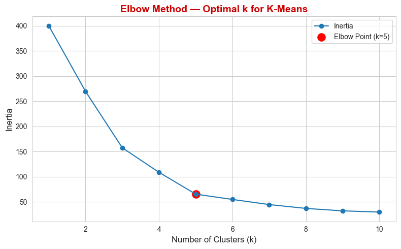

```python
plt.figure(figsize=(8, 5))

plt.plot(range(1, 11), inertia, marker="o", label="Inertia")
plt.scatter(5, inertia[4], color="red", s=120, label="Elbow Point (k=5)")

plt.title("Elbow Method — Optimal k for K-Means", color="#CC0000", fontweight="bold")
plt.xlabel("Number of Clusters (k)")
plt.ylabel("Inertia")
plt.legend()

plt.tight_layout()
plt.savefig("../screenshots/elbow_method.png", dpi=300, bbox_inches="tight")
plt.show()
```

#### Interpretation

- The Elbow Method plots the **inertia** against different values of **k** (number of clusters).
- **Inertia** measures the total within-cluster sum of squared distances. Lower inertia indicates more compact clusters.
- The curve shows a noticeable bend around **k = 5**, after which the reduction in inertia becomes gradual.
- Therefore, **k = 5** is considered a suitable choice because it provides a good balance between cluster quality and model complexity.

### Task 3.2: Silhouette Score

```python
silhouette_scores = []

for k in range(2, 11):
    kmeans = KMeans(n_clusters=k, random_state=42, n_init=10)

    cluster_labels = kmeans.fit_predict(df_2f)
    score = silhouette_score(df_2f, cluster_labels)
    silhouette_scores.append(score)
```

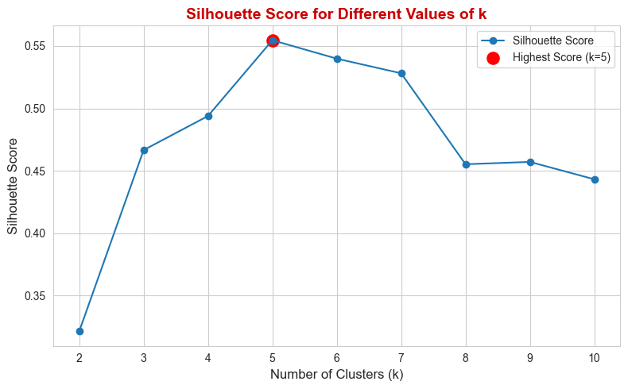

```python
optimal_k = range(2, 11)[np.argmax(silhouette_scores)]

plt.figure(figsize=(8, 5))

plt.plot(range(2, 11), silhouette_scores, marker="o", label="Silhouette Score")
plt.scatter(optimal_k, max(silhouette_scores), color="red", s=120, label=f"Highest Score (k={optimal_k})")

plt.title("Silhouette Score for Different Values of k", color="#CC0000", fontweight="bold")
plt.xlabel("Number of Clusters (k)")
plt.ylabel("Silhouette Score")
plt.legend()

plt.tight_layout()
plt.savefig("../screenshots/silhouette_score.png", dpi=300, bbox_inches="tight")
plt.show()
```

### Task 3.3: Fit Final K-Means Model

```python
kmeans = KMeans(n_clusters=5, random_state=42, n_init=10)

df["KMeans_Cluster"] = kmeans.fit_predict(df_2f)
df.head()
```

|  | Gender | Age | Annual_Income | Spending_Score | KMeans_Cluster |
| --- | --- | --- | --- | --- | --- |
| 0 | 1 | 19 | 15 | 39 | 4 |
| 1 | 1 | 21 | 15 | 81 | 2 |
| 2 | 0 | 20 | 16 | 6 | 4 |
| 3 | 0 | 23 | 16 | 77 | 2 |
| 4 | 0 | 31 | 17 | 40 | 4 |

### Task 3.4: Visualize K-Means Clusters

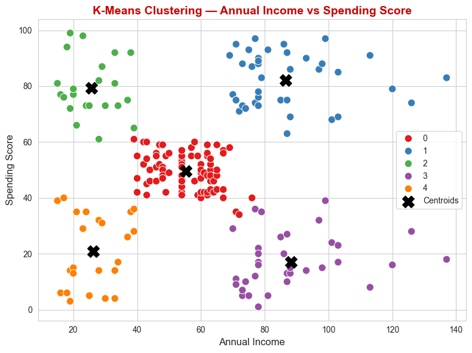

```python
centroids = scaler.inverse_transform(np.column_stack([np.zeros(len(kmeans.cluster_centers_)), kmeans.cluster_centers_]))[:, 1:]

plt.figure(figsize=(8, 6))

sns.scatterplot(x="Annual_Income", y="Spending_Score", hue="KMeans_Cluster", data=df, palette="Set1", s=80)
plt.scatter(centroids[:, 0], centroids[:, 1], c="black", marker="X", s=200, label="Centroids")

plt.title("K-Means Clustering — Annual Income vs Spending Score", color="#CC0000", fontweight="bold")
plt.xlabel("Annual Income")
plt.ylabel("Spending Score")
plt.legend()

plt.tight_layout()
plt.savefig("../screenshots/kmeans_clusters.png", dpi=300, bbox_inches="tight")
plt.show()
```

#### Interpretation

- The plot shows five distinct customer clusters based on **Annual Income** and **Spending Score**.
- The black **X** markers represent the centroid of each cluster.

### Task 3.5: Cluster Profile Table

```python
cluster_profile = (df.groupby("KMeans_Cluster")[["Age", "Annual_Income", "Spending_Score"]].mean().round(2))
cluster_profile.style.background_gradient(cmap="Blues")
```

| KMeans_Cluster | Age | Annual_Income | Spending_Score |
| --- | --- | --- | --- |
| 0 | 42.720000 | 55.300000 | 49.520000 |
| 1 | 32.690000 | 86.540000 | 82.130000 |
| 2 | 25.270000 | 25.730000 | 79.360000 |
| 3 | 41.110000 | 88.200000 | 17.110000 |
| 4 | 45.220000 | 26.300000 | 20.910000 |

#### Business Insights

Based on the cluster profile table, the customer segments can be identified as:

- **High Income, High Spenders:** Premium customers who are likely to respond well to exclusive offers, loyalty programs, and luxury products.
- **High Income, Low Spenders:** Customers with strong purchasing potential who can be targeted using personalized promotions and discounts.
- **Low Income, High Spenders:** Customers who spend actively despite lower income and may respond well to seasonal offers and reward programs.
- **Low Income, Low Spenders:** Budget-conscious customers who are more attracted to value-for-money products and discounts.
- **Moderate Income, Moderate Spenders:** Regular customers who contribute to consistent sales and can be retained through membership benefits and personalized marketing.

# Task 4: Agglomerative Hierarchical Clustering

### Objective

Perform Agglomerative Hierarchical Clustering, determine the optimal number of clusters using a dendrogram, visualize the clusters, and compare the results with K-Means.

### Expected Output

- Dendrogram using Ward linkage.
- Agglomerative clustering model.
- Cluster visualization.
- Comparison with K-Means.
- Cluster profile table.

### Task 4.1: Dendrogram

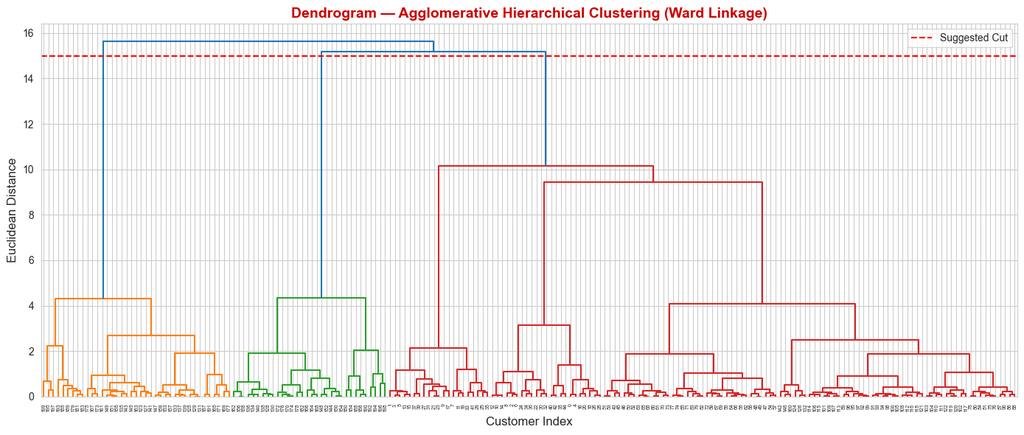

```python
linked = linkage(df_2f, method="ward")

plt.figure(figsize=(14, 6))

dendrogram(linked)
plt.axhline(y=15, color="red", linestyle="--", label="Suggested Cut")

plt.title("Dendrogram — Agglomerative Hierarchical Clustering (Ward Linkage)", color="#CC0000", fontweight="bold")
plt.xlabel("Customer Index")
plt.ylabel("Euclidean Distance")
plt.legend()

plt.tight_layout()
plt.savefig("../screenshots/dendrogram.png", dpi=300, bbox_inches="tight")
plt.show()
```

#### Interpretation

- Ward linkage minimizes the variance within each cluster while merging the closest clusters.
- The optimal number of clusters is chosen by drawing a horizontal line through the largest vertical gap in the dendrogram.

### Task 4.2: Fit Agglomerative Model

```python
hierarchical = AgglomerativeClustering(n_clusters=5, linkage="ward")

df["Hier_Cluster"] = hierarchical.fit_predict(df_2f)
df.head()
```

|  | Gender | Age | Annual_Income | Spending_Score | KMeans_Cluster | Hier_Cluster |
| --- | --- | --- | --- | --- | --- | --- |
| 0 | 1 | 19 | 15 | 39 | 4 | 4 |
| 1 | 1 | 21 | 15 | 81 | 2 | 3 |
| 2 | 0 | 20 | 16 | 6 | 4 | 4 |
| 3 | 0 | 23 | 16 | 77 | 2 | 3 |
| 4 | 0 | 31 | 17 | 40 | 4 | 4 |

### Task 4.3: Visualize Hierarchical Clusters

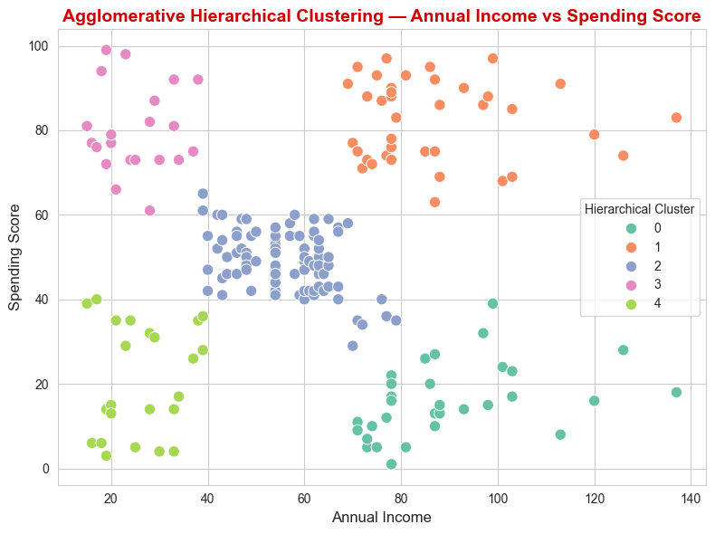

```python
plt.figure(figsize=(8, 6))

sns.scatterplot(x="Annual_Income", y="Spending_Score", hue="Hier_Cluster", data=df, palette="Set2", s=80)

plt.title("Agglomerative Hierarchical Clustering — Annual Income vs Spending Score", color="#CC0000", fontweight="bold")
plt.xlabel("Annual Income")
plt.ylabel("Spending Score")
plt.legend(title="Hierarchical Cluster")

plt.tight_layout()
plt.savefig("../screenshots/hierarchical_clusters.png", dpi=300, bbox_inches="tight")
plt.show()
```

#### Interpretation

- The scatter plot shows the customer groups formed using Agglomerative Hierarchical Clustering.
- Customers within the same color belong to the same hierarchical cluster.

### Task 4.4: Compare with K-Means

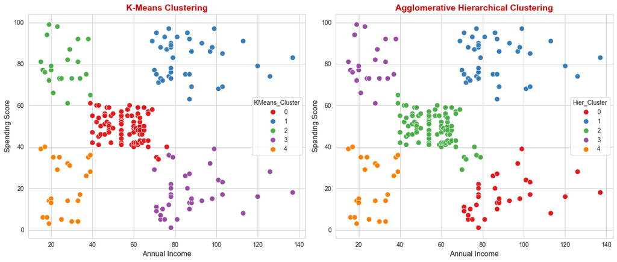

```python
plt.figure(figsize=(14, 6))

# K-Means
plt.subplot(1, 2, 1)
sns.scatterplot(x="Annual_Income", y="Spending_Score", hue="KMeans_Cluster", data=df, palette="Set1", s=70)

plt.title("K-Means Clustering", color="#CC0000", fontweight="bold")
plt.xlabel("Annual Income")
plt.ylabel("Spending Score")

# Hierarchical
plt.subplot(1, 2, 2)
sns.scatterplot(x="Annual_Income", y="Spending_Score", hue="Hier_Cluster", data=df, palette="Set1", s=70)

plt.title("Agglomerative Hierarchical Clustering", color="#CC0000", fontweight="bold")
plt.xlabel("Annual Income")
plt.ylabel("Spending Score")

plt.tight_layout()
plt.savefig("../screenshots/kmeans_vs_hierarchical.png", dpi=300, bbox_inches="tight")
plt.show()
```

#### Interpretation

- Both algorithms identify similar customer groups, although some border-region customers are assigned to different clusters.
- K-Means is **centroid-based**, while Agglomerative Clustering is **connectivity-based**, so slight differences in cluster boundaries are expected.

### Task 4.5: Cluster Profile Table

```python
hier_profile = (df.groupby("Hier_Cluster")[["Age", "Annual_Income", "Spending_Score"]].mean().round(2))
hier_profile.style.background_gradient(cmap="Greens")
```

| Hier_Cluster | Age | Annual_Income | Spending_Score |
| --- | --- | --- | --- |
| 0 | 41.000000 | 89.410000 | 15.590000 |
| 1 | 32.690000 | 86.540000 | 82.130000 |
| 2 | 42.480000 | 55.810000 | 49.130000 |
| 3 | 25.330000 | 25.100000 | 80.050000 |
| 4 | 45.220000 | 26.300000 | 20.910000 |

#### Interpretation

- The Hierarchical Clustering profiles are largely consistent with the K-Means cluster profiles.
- Minor differences in the mean values may occur because Hierarchical Clustering groups customers based on connectivity, whereas K-Means groups them based on distance from cluster centroids.

# Task 5: DBSCAN Clustering

### Objective

Apply DBSCAN clustering by selecting suitable parameters, identify noise points, visualize the clusters, and compare the results with K-Means and Hierarchical Clustering.

### Expected Output

- 4-NN Distance Plot.
- DBSCAN parameter tuning results.
- Final DBSCAN model.
- Cluster visualization with noise points.
- Comparison with K-Means.

### Task 5.1: Parameter Tuning – Epsilon

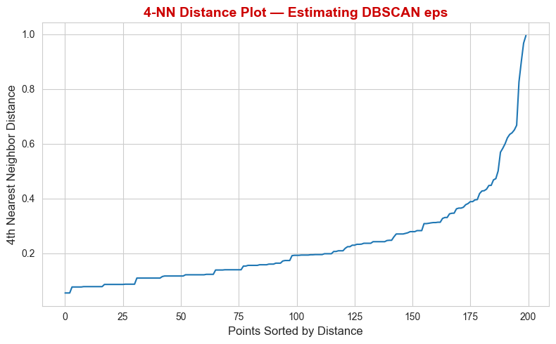

```python
nearest_neighbors = NearestNeighbors(n_neighbors=4)

neighbors = nearest_neighbors.fit(df_2f)
distances, indices = neighbors.kneighbors(df_2f)
distances = np.sort(distances[:, 3])

plt.figure(figsize=(8, 5))

plt.plot(distances)

plt.title("4-NN Distance Plot — Estimating DBSCAN eps", color="#CC0000", fontweight="bold")
plt.xlabel("Points Sorted by Distance")
plt.ylabel("4th Nearest Neighbor Distance")

plt.tight_layout()
plt.savefig("../screenshots/dbscan_eps_plot.png", dpi=300, bbox_inches="tight")
plt.show()
```

#### Interpretation

- The bend (knee) in the curve suggests a suitable value for the **eps** parameter.
- Choosing an eps near this point helps identify dense clusters while minimizing noise.

### Task 5.2: Grid Search for eps and min_samples

```python
eps_values = [0.2, 0.3, 0.4, 0.5, 0.6]
min_samples_values = [3, 4, 5, 6]

results = []

for eps in eps_values:
    for min_samples in min_samples_values:

        dbscan = DBSCAN(eps=eps, min_samples=min_samples)
        labels = dbscan.fit_predict(df_2f)
        n_clusters = len(set(labels)) - (1 if -1 in labels else 0)
        noise_points = list(labels).count(-1)

        if n_clusters > 1:
            mask = labels != -1
            score = silhouette_score(df_2f[mask], labels[mask])
        else:
            score = np.nan

        results.append({
            "eps": eps,
            "min_samples": min_samples,
            "Clusters": n_clusters,
            "Noise_Points": noise_points,
            "Silhouette_Score": round(score, 3) if not np.isnan(score) else np.nan
        })

dbscan_results = pd.DataFrame(results)
dbscan_results.sort_values(by=["Silhouette_Score", "Noise_Points"], ascending=[False, True]).reset_index(drop=True)
```

|  | eps | min_samples | Clusters | Noise_Points | Silhouette_Score |
| --- | --- | --- | --- | --- | --- |
| 0 | 0.2 | 4 | 5 | 73 | 0.617 |
| 1 | 0.2 | 6 | 4 | 95 | 0.614 |
| 2 | 0.2 | 5 | 7 | 77 | 0.586 |
| 3 | 0.3 | 6 | 6 | 48 | 0.530 |
| 4 | 0.3 | 5 | 7 | 35 | 0.524 |
| 5 | 0.3 | 4 | 8 | 23 | 0.520 |
| 6 | 0.4 | 6 | 4 | 19 | 0.490 |
| 7 | 0.4 | 5 | 4 | 15 | 0.478 |
| 8 | 0.3 | 3 | 9 | 14 | 0.472 |
| 9 | 0.2 | 3 | 13 | 44 | 0.470 |
| 10 | 0.4 | 4 | 3 | 14 | 0.458 |
| 11 | 0.5 | 6 | 2 | 11 | 0.401 |
| 12 | 0.4 | 3 | 4 | 10 | 0.395 |
| 13 | 0.5 | 3 | 2 | 7 | 0.389 |
| 14 | 0.5 | 4 | 2 | 8 | 0.388 |
| 15 | 0.5 | 5 | 2 | 8 | 0.388 |
| 16 | 0.6 | 3 | 1 | 0 | NaN |
| 17 | 0.6 | 4 | 1 | 5 | NaN |
| 18 | 0.6 | 5 | 1 | 5 | NaN |
| 19 | 0.6 | 6 | 1 | 6 | NaN |

### Selected Parameters

Based on the grid search results, **eps = 0.3** and **min_samples = 4** were selected because they produced **8 clusters**, **23 noise points**, and a **silhouette score of 0.520**, providing coherent clusters with a good balance between cluster quality and noise.

### Task 5.3: Fit Final DBSCAN Model

```python
dbscan = DBSCAN(eps=0.3, min_samples=4)

df["DBSCAN_Cluster"] = dbscan.fit_predict(df_2f)
df.head()
```

|  | Gender | Age | Annual_Income | Spending_Score | KMeans_Cluster | Hier_Cluster | DBSCAN_Cluster |
| --- | --- | --- | --- | --- | --- | --- | --- |
| 0 | 1 | 19 | 15 | 39 | 4 | 4 | 2 |
| 1 | 1 | 21 | 15 | 81 | 2 | 3 | 0 |
| 2 | 0 | 20 | 16 | 6 | 4 | 4 | 1 |
| 3 | 0 | 23 | 16 | 77 | 2 | 3 | 0 |
| 4 | 0 | 31 | 17 | 40 | 4 | 4 | 2 |

### Task 5.4: Visualize DBSCAN Clusters

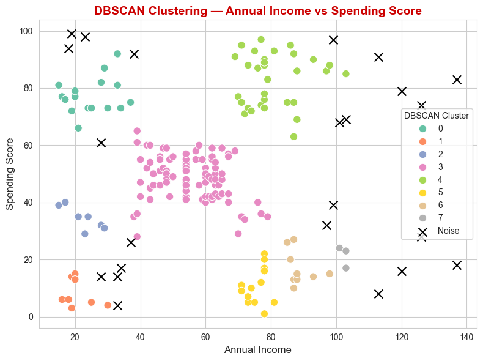

```python
plt.figure(figsize=(8, 6))

# Clustered points
sns.scatterplot(x="Annual_Income", y="Spending_Score", hue="DBSCAN_Cluster", data=df[df["DBSCAN_Cluster"] != -1], palette="Set2", s=80)

# Noise points
noise = df[df["DBSCAN_Cluster"] == -1]

plt.scatter(noise["Annual_Income"], noise["Spending_Score"], color="black", marker="x", s=100, label="Noise")

plt.title("DBSCAN Clustering — Annual Income vs Spending Score", color="#CC0000", fontweight="bold")
plt.xlabel("Annual Income")
plt.ylabel("Spending Score")
plt.legend(title="DBSCAN Cluster")

plt.tight_layout()
plt.savefig("../screenshots/dbscan_clusters.png", dpi=300, bbox_inches="tight")
plt.show()
```

#### Interpretation

- **eps** defines the maximum distance between nearby points to be considered part of the same neighborhood.
- **min_samples** specifies the minimum number of neighboring points required to form a dense cluster.
- Points that are too far from any dense region do not satisfy these conditions and are labeled as **noise (`-1`)**.

### Task 5.5: DBSCAN vs K-Means — Shape Detection

# Task 6: Algorithm Comparison & Business Insights

### Objective

Compare the clustering algorithms using visualizations and evaluation metrics, then derive actionable business insights from the customer segments.

### Expected Output

- Three-panel comparison plot.
- Metrics summary table.
- Business insight report with marketing recommendations.

### Task 6.1: Three-Panel Comparison Figure

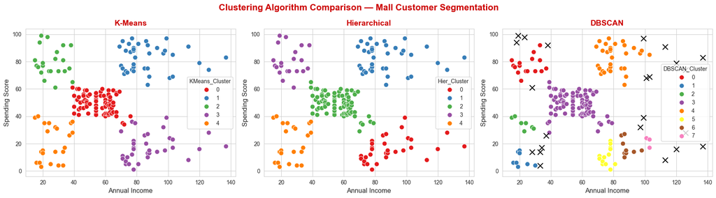

```python
plt.figure(figsize=(18, 5))

# K-Means
plt.subplot(1, 3, 1)

sns.scatterplot(x="Annual_Income", y="Spending_Score", hue="KMeans_Cluster", data=df, palette="Set1", s=70)

plt.title("K-Means", color="#CC0000", fontweight="bold")
plt.xlabel("Annual Income")
plt.ylabel("Spending Score")


# Hierarchical
plt.subplot(1, 3, 2)

sns.scatterplot(x="Annual_Income", y="Spending_Score", hue="Hier_Cluster", data=df, palette="Set1", s=70)

plt.title("Hierarchical", color="#CC0000", fontweight="bold")
plt.xlabel("Annual Income")
plt.ylabel("Spending Score")


# DBSCAN
plt.subplot(1, 3, 3)

sns.scatterplot(x="Annual_Income", y="Spending_Score", hue="DBSCAN_Cluster", data=df[df["DBSCAN_Cluster"] != -1], palette="Set1", s=70)

noise = df[df["DBSCAN_Cluster"] == -1]

plt.scatter(noise["Annual_Income"], noise["Spending_Score"], color="black", marker="x", s=90, label="Noise")

plt.title("DBSCAN", color="#CC0000", fontweight="bold")
plt.xlabel("Annual Income")
plt.ylabel("Spending Score")

plt.suptitle("Clustering Algorithm Comparison — Mall Customer Segmentation", color="#CC0000", fontweight="bold", fontsize=16)
plt.tight_layout()

plt.savefig("../screenshots/algorithm_comparison.png", dpi=300, bbox_inches="tight")
plt.show()
```

#### Interpretation

- K-Means and Hierarchical Clustering produce similar customer segments, while DBSCAN additionally identifies noise points and clusters based on data density.
- The comparison highlights how different clustering algorithms partition the same customer data using different underlying approaches.

### Task 6.2: Metrics Summary Table

```python
# Number of clusters
kmeans_clusters = df["KMeans_Cluster"].nunique()
hier_clusters = df["Hier_Cluster"].nunique()

dbscan_clusters = (df[df["DBSCAN_Cluster"] != -1]["DBSCAN_Cluster"].nunique())

# Silhouette Scores
kmeans_silhouette = silhouette_score(df_2f, df["KMeans_Cluster"])
hier_silhouette = silhouette_score(df_2f, df["Hier_Cluster"])

# Exclude noise points for DBSCAN
dbscan_data = df_2f[df["DBSCAN_Cluster"] != -1]
dbscan_labels = df.loc[df["DBSCAN_Cluster"] != -1, "DBSCAN_Cluster"]

dbscan_silhouette = silhouette_score(dbscan_data, dbscan_labels)

# Summary Table
metrics_summary = pd.DataFrame({
    "Algorithm": ["K-Means", "Hierarchical", "DBSCAN"],
    "n_clusters": [kmeans_clusters, hier_clusters, dbscan_clusters],
    "Silhouette Score": [round(kmeans_silhouette, 3), round(hier_silhouette, 3), round(dbscan_silhouette, 3)]})

metrics_summary
```

|  | Algorithm | n_clusters | Silhouette Score |
| --- | --- | --- | --- |
| 0 | K-Means | 5 | 0.555 |
| 1 | Hierarchical | 5 | 0.554 |
| 2 | DBSCAN | 8 | 0.520 |

#### Explanation

- The algorithm with the **highest Silhouette Score** provides the best balance between compact and well-separated clusters.
- **K-Means** is generally preferred for this dataset because it produces clear, interpretable customer segments while achieving strong clustering performance.

### Task 6.3: Business Insights for Mall Management

## Business Insights for Mall Management

### Customer Segments (K-Means)

| Customer Segment | Characteristics | Recommended Marketing Action |
| --- | --- | --- |
| High Income, High Spending | Premium customers with high purchasing power. | Offer loyalty rewards, VIP memberships, and exclusive product launches. |
| High Income, Low Spending | Affluent customers who spend cautiously. | Provide personalized offers and premium product recommendations to encourage purchases. |
| Low Income, High Spending | Value-conscious customers who spend actively. | Introduce budget-friendly promotions, discounts, and seasonal offers. |
| Low Income, Low Spending | Customers with limited purchasing activity. | Use entry-level promotions and awareness campaigns to increase engagement. |
| Moderate Income, Moderate Spending | Regular customers with balanced shopping behavior. | Maintain engagement through reward points and personalized recommendations. |

### Recommended Algorithm

- **K-Means** is recommended for deployment because it produces clear and easily interpretable customer segments, making it suitable for business decision-making and marketing strategies.
- **DBSCAN** is preferable when customer groups have irregular shapes or when identifying noise and outliers is important.
- **Hierarchical Clustering** is most useful when a dendrogram is required to visualize relationships between customer groups for management presentations.